# ICB Plots

Tianxiang

2026-09-07

# Common settings and functions

# Long-term Results

H1.1 Regime Type

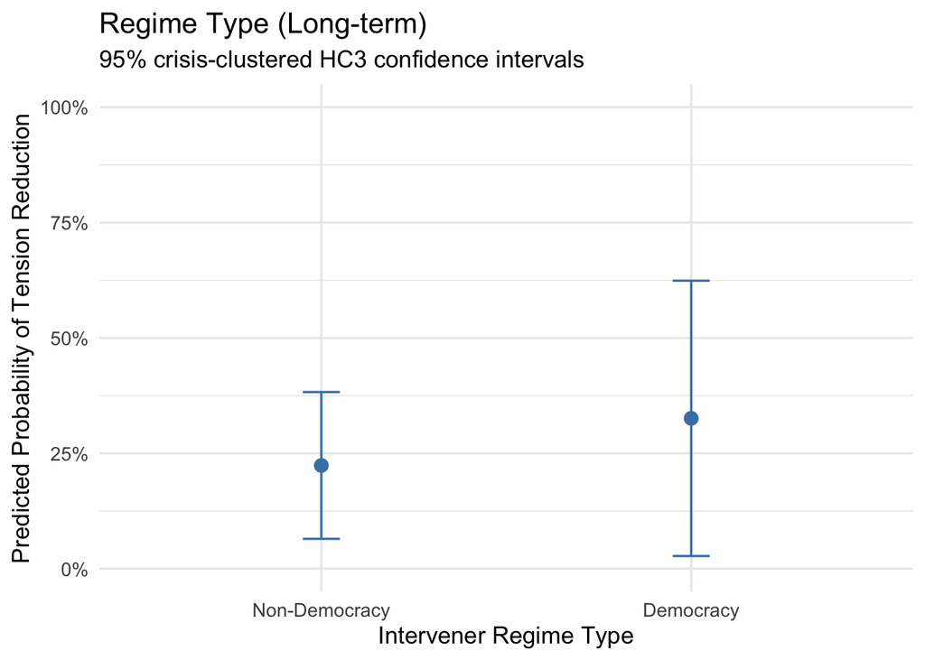

H1.2 Personalism

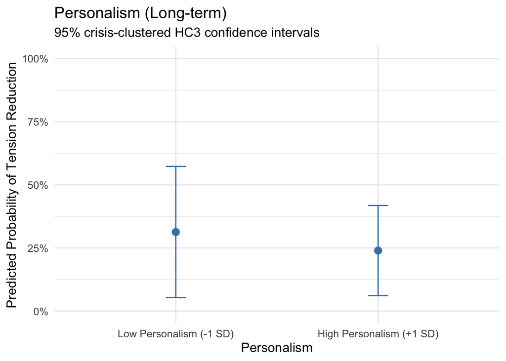

H1.3 Regime Type * Military Expenditure

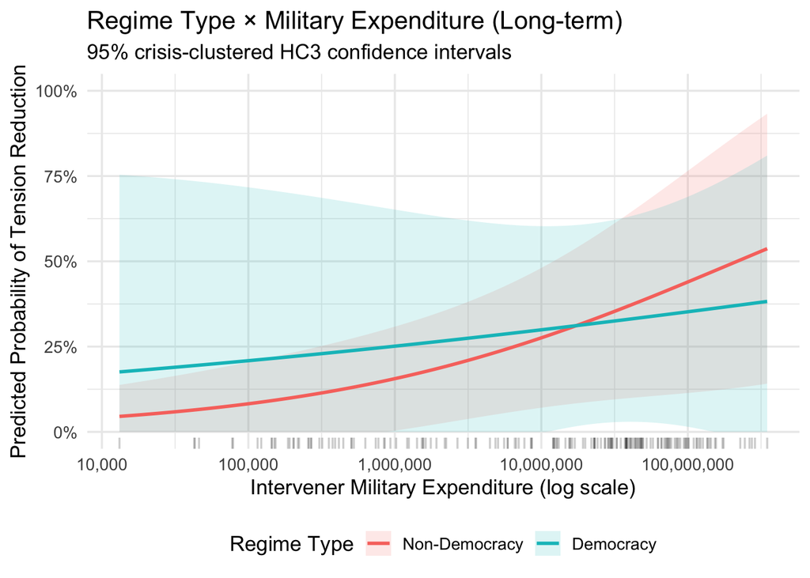

H1.4 Personalism * Military Expenditure

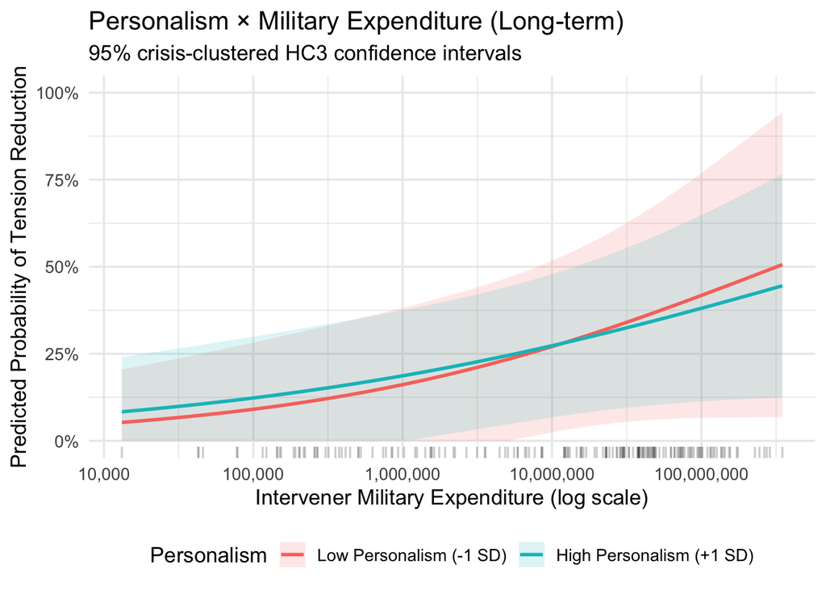

H1.5 Regime Type * Ties to Both Sides

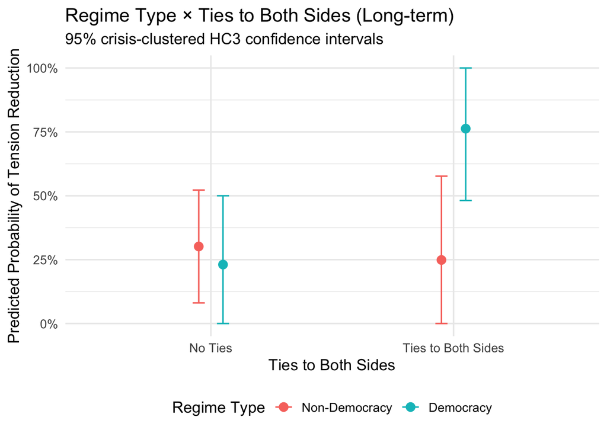

H1.6 Personalism * Ties to Both Sides

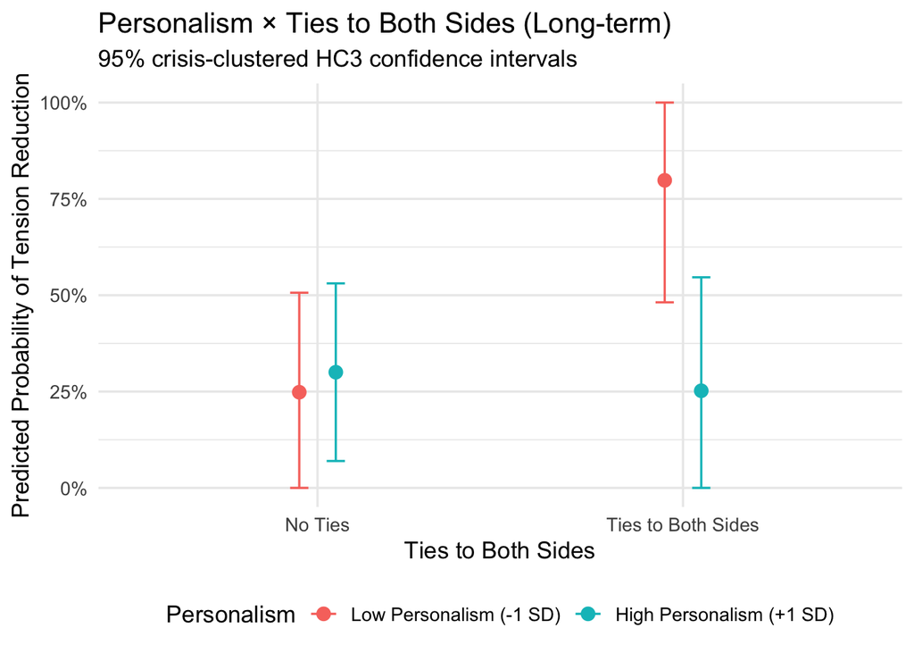

H1.7 Human Rights * Ties to Both Sides

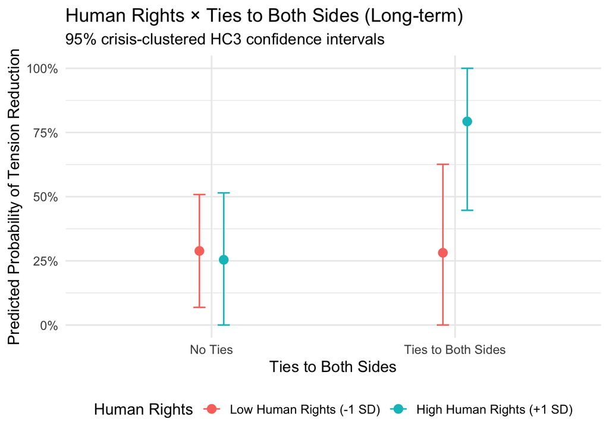

H1.8 Human Rights * Military Expenditure

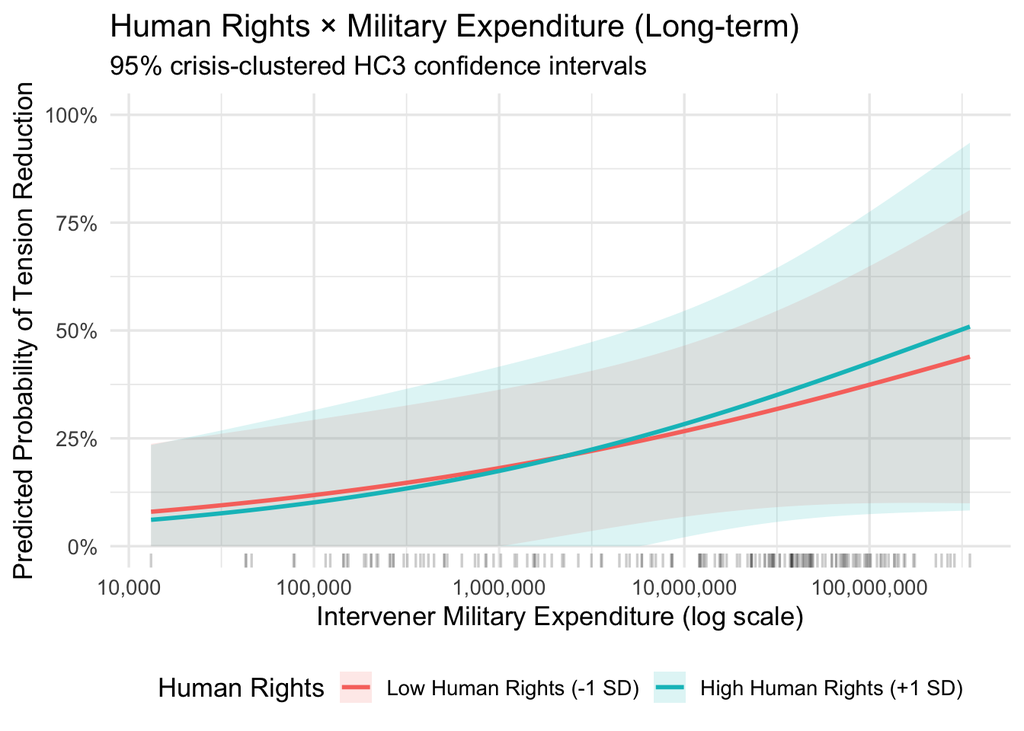

H1.9 Electoral Democracy * Military Expenditure

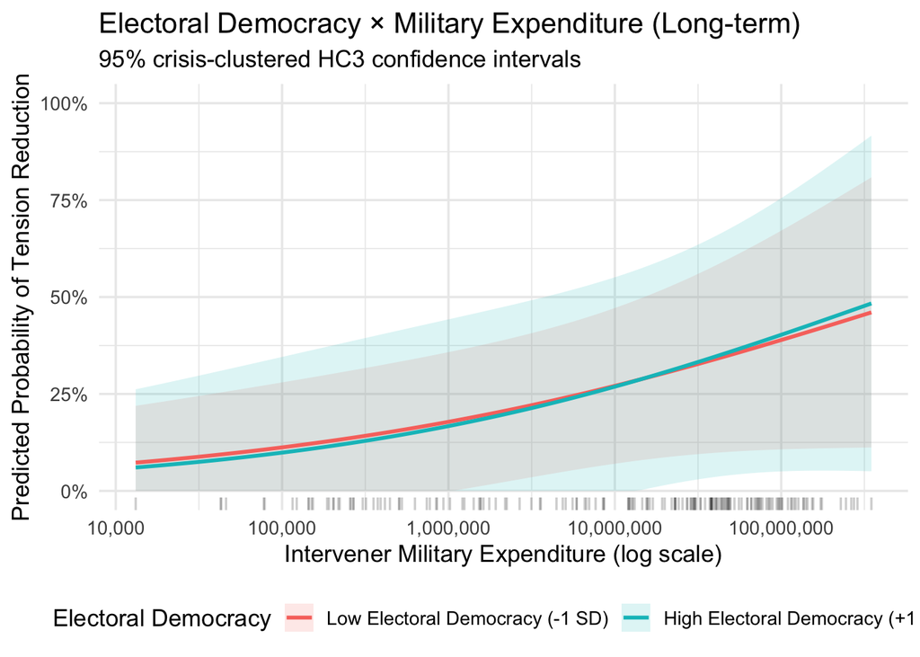

H1.10 Transparency * Military Expenditure

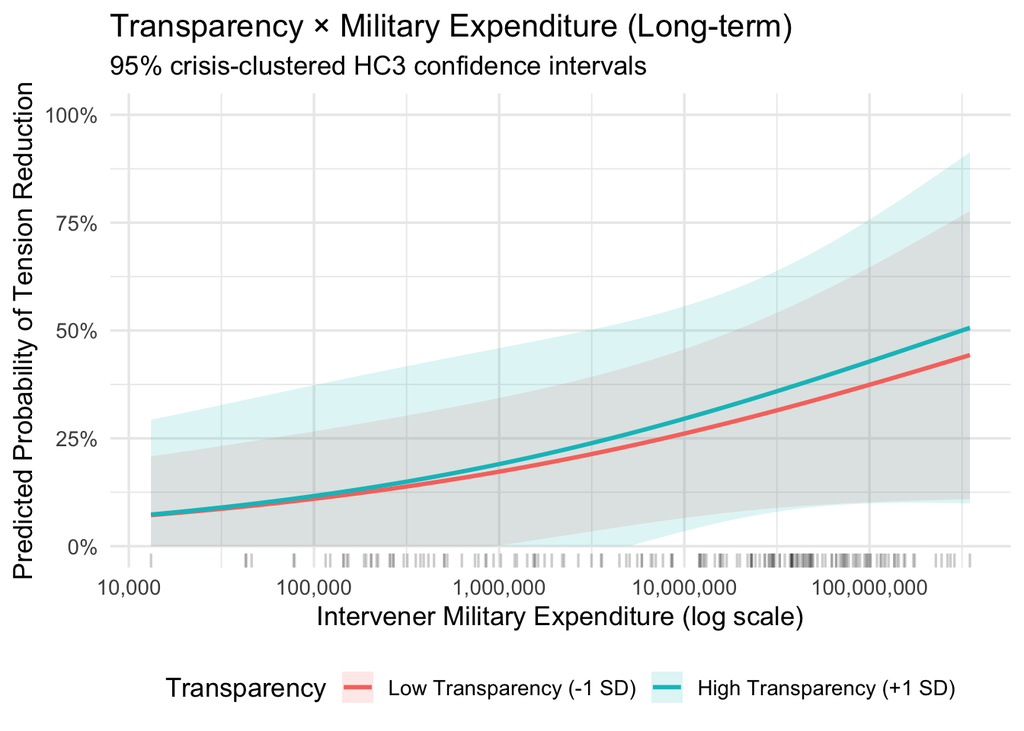

H1.11 Electoral Democracy * Ties to Both Sides

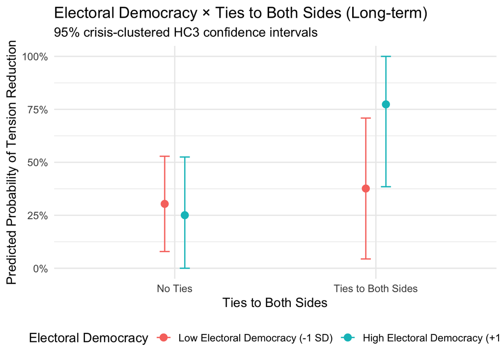

H1.12 Transparency * Ties to Both Sides

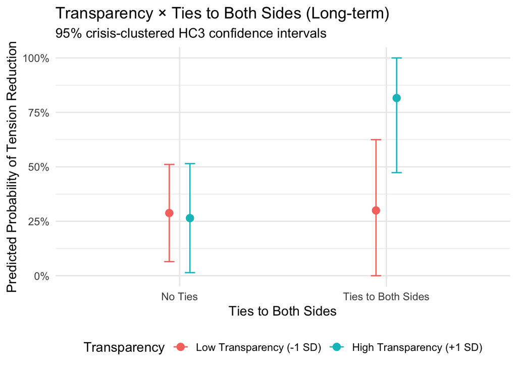

# Short-term Results

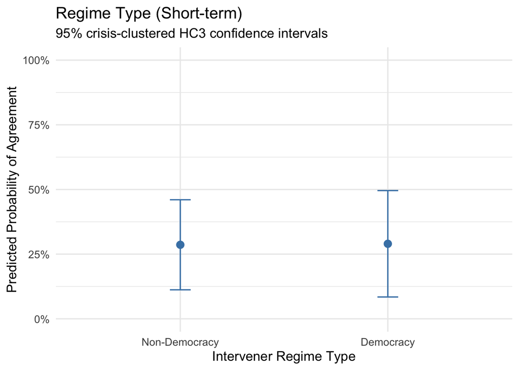

H2.2 Personalism

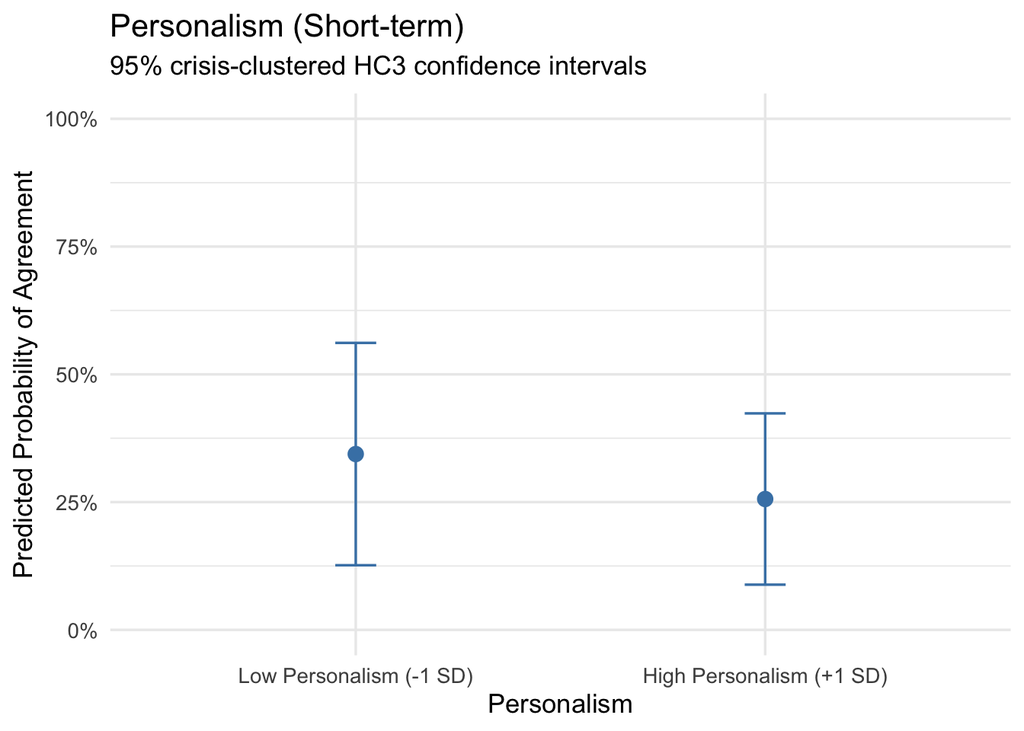

H2.3 Regime type × Military expenditure

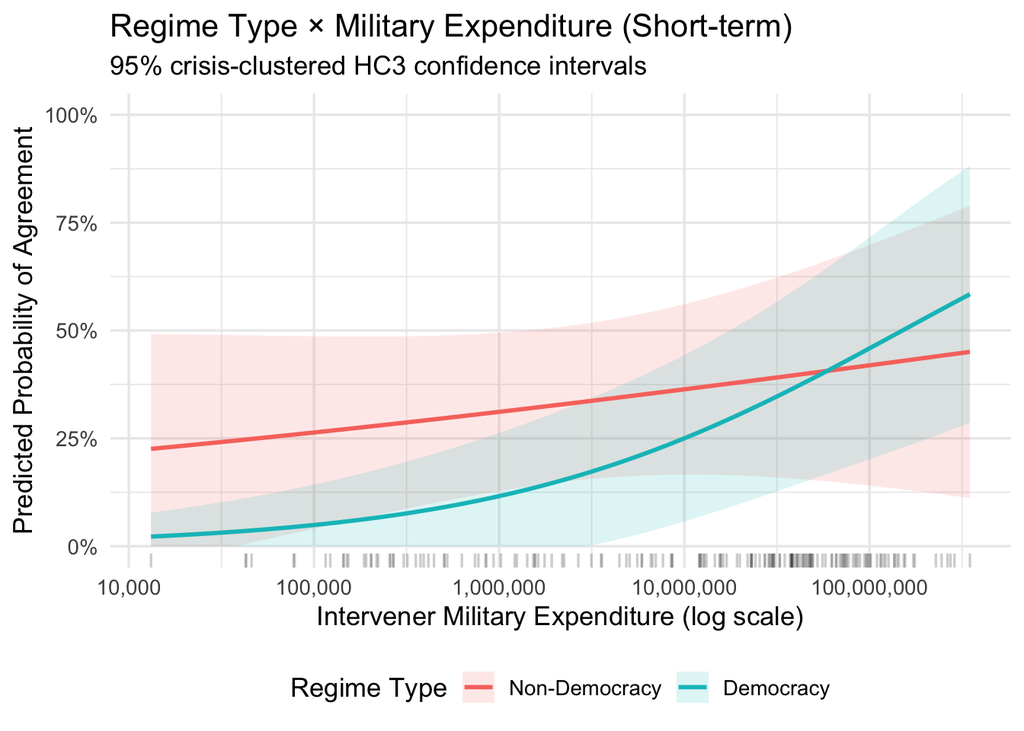

H2.4 Personalism × Military expenditure

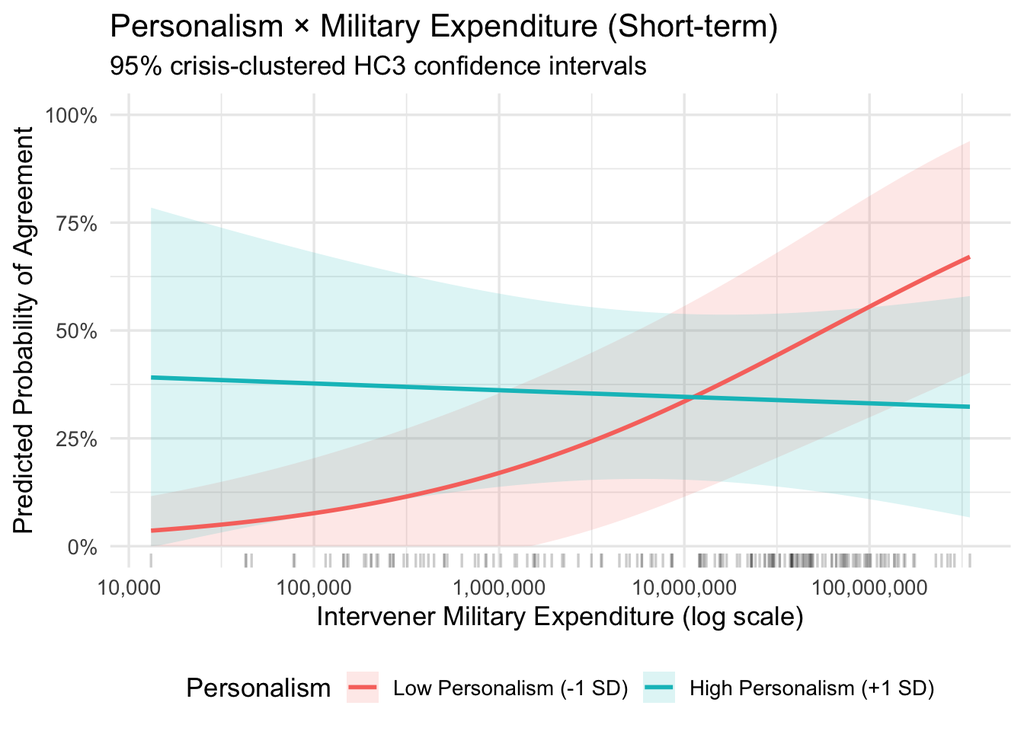

H2.5 Regime Type * Ties to Both Sides

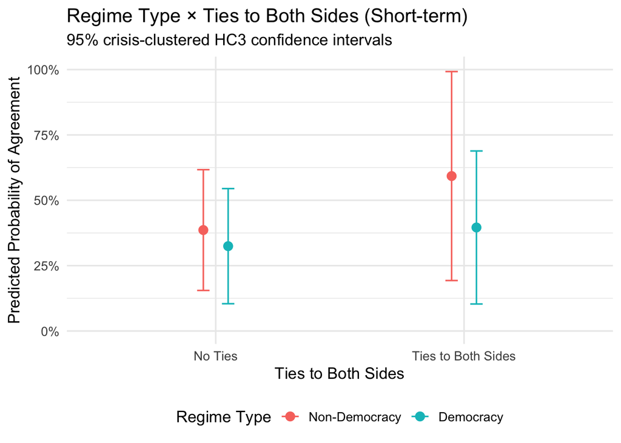

H2.6 Personalism × Ties to both sides

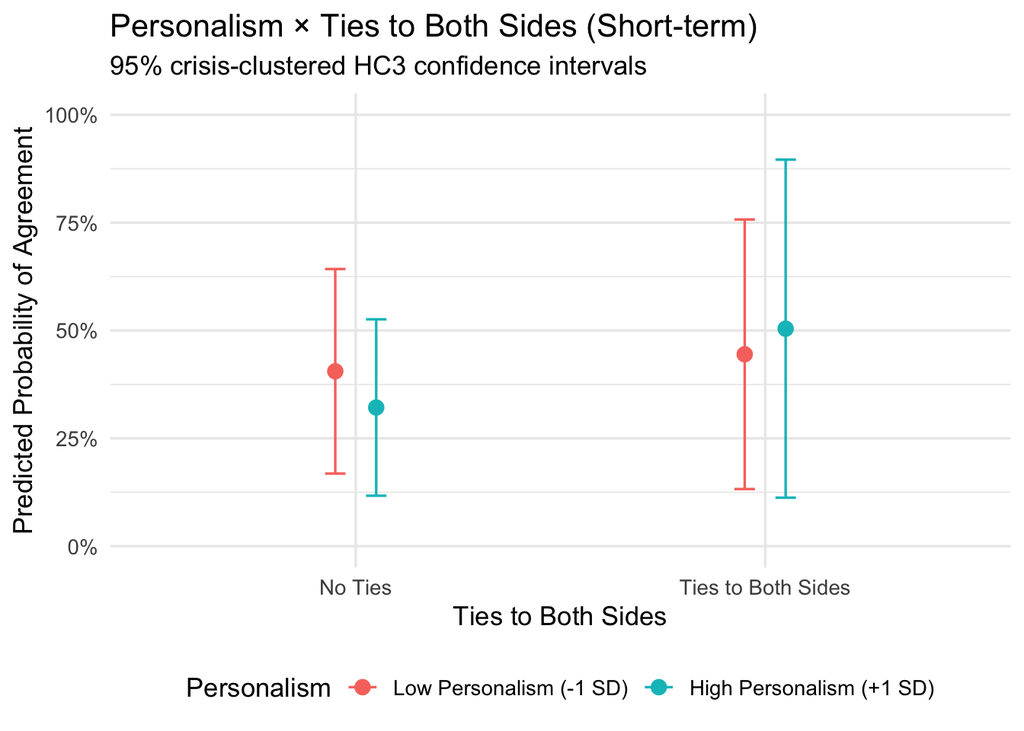

H2.7: Human Rights * Ties to Both Sides

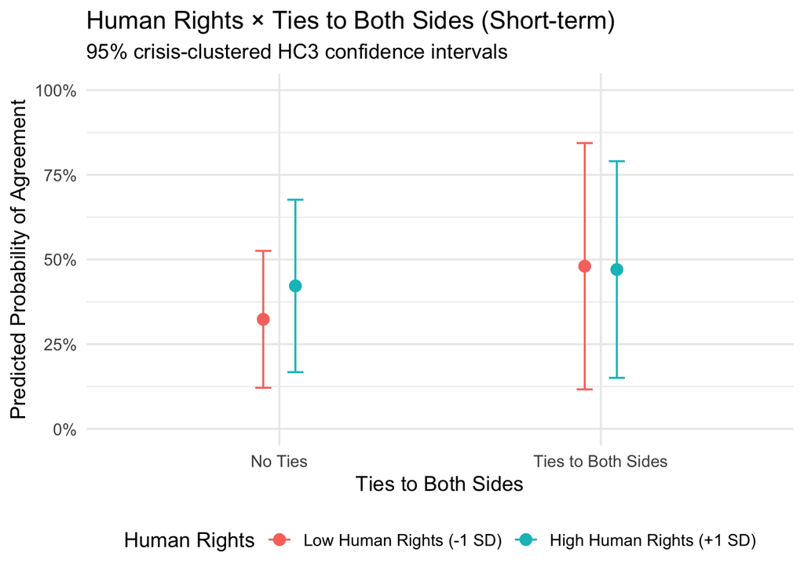

H2.8 Human Rights * Military Expenditure

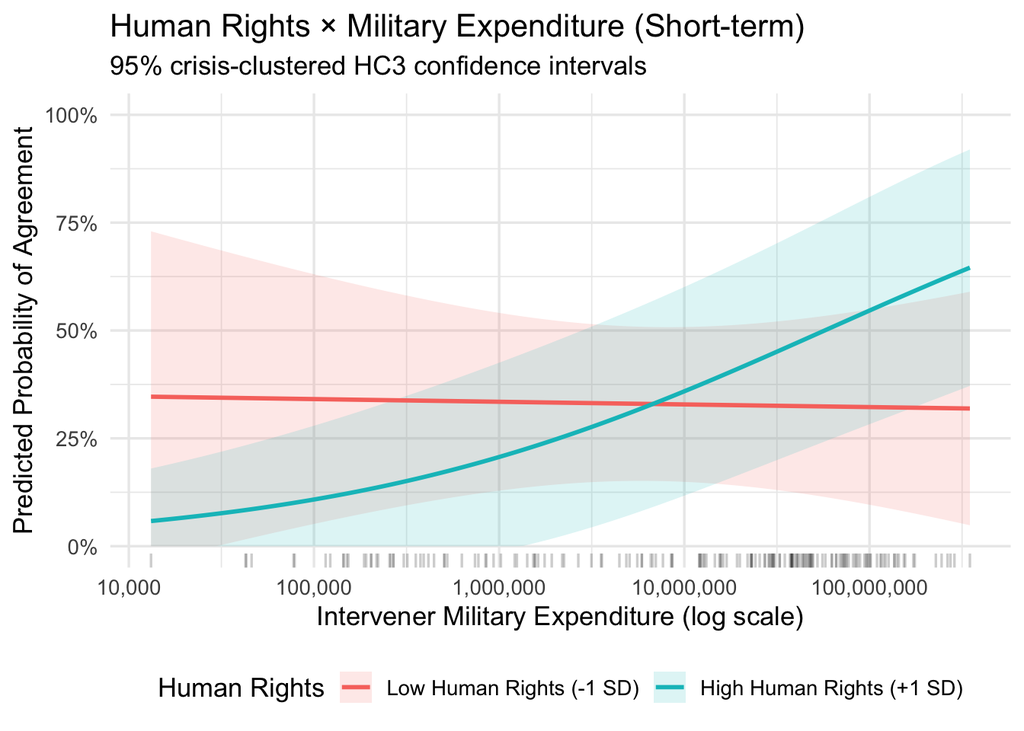

H2.9 Electoral Democracy * Military Expenditure

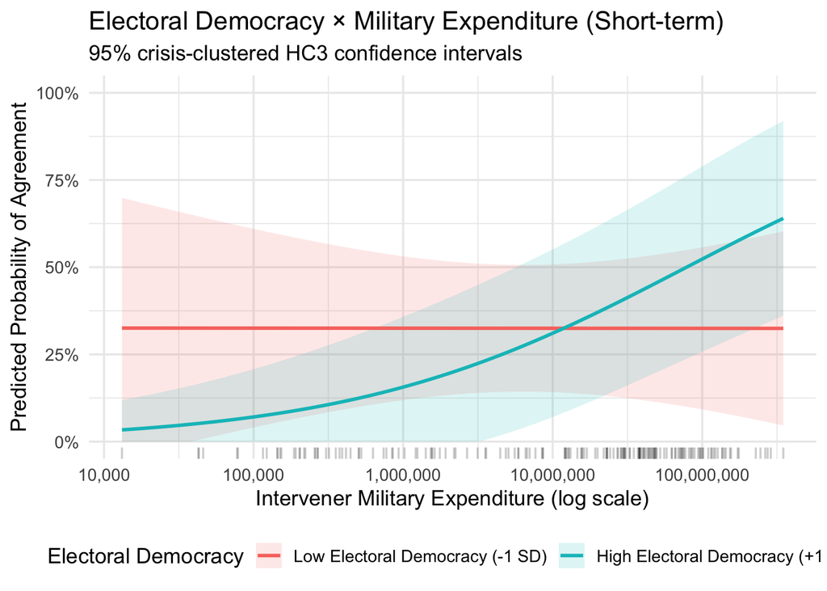

H2.10 Transparency * Military Expenditure

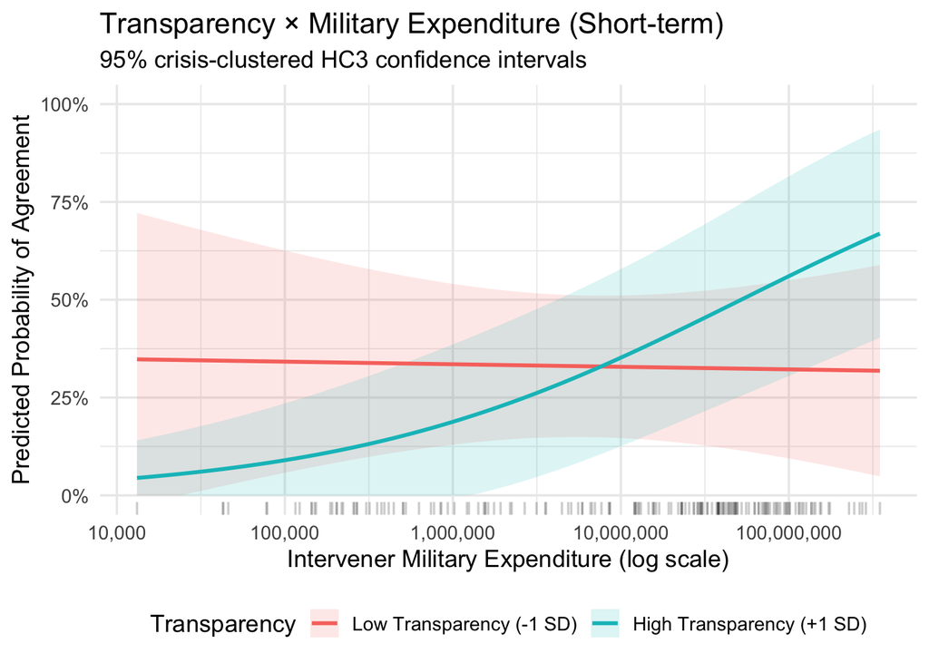

H2.11 Electoral Demo * Ties to Both Sides

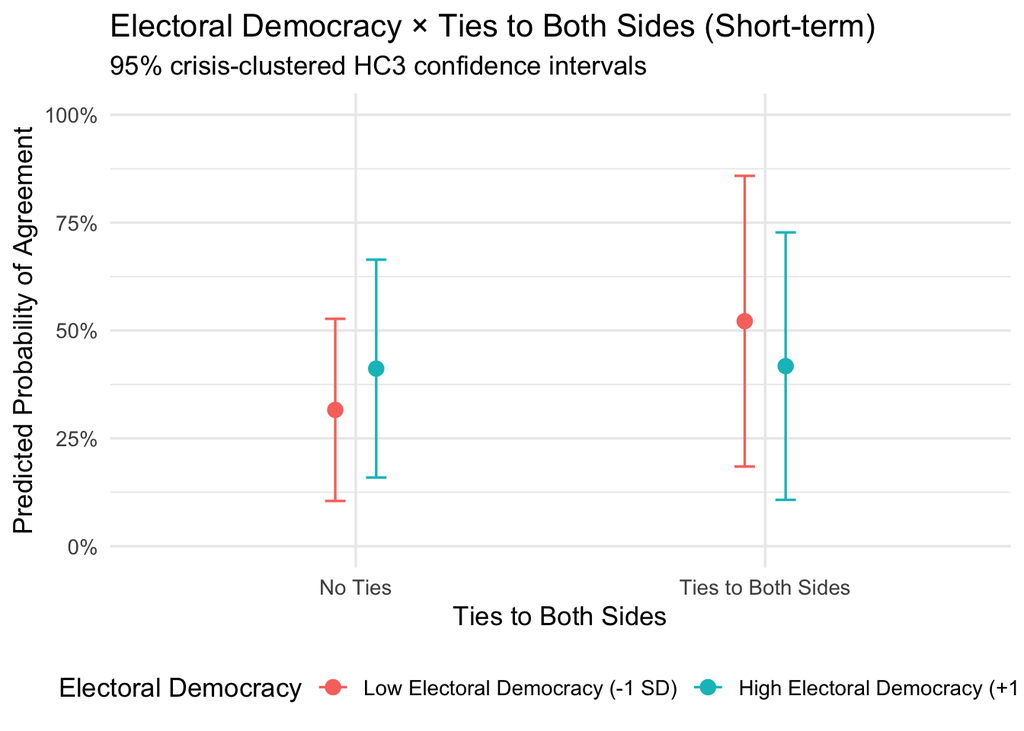

H2.12 Transparency * Ties to Both Sides

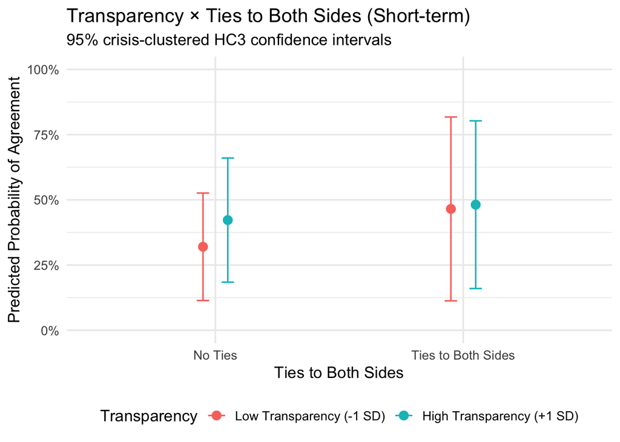

```r
model_data_2.12 <- get_model_data(
  h2.12_without_US
)

transparency_values_2.12 <- get_mean_sd(
  model_data_2.12,
  "transparency"
)

figure_2.12 <- make_ties_interaction_plot(
  model = h2.12_without_US,
  moderator = "transparency",
  moderator_values = transparency_values_2.12,
  moderator_labels = c(
    "Low Transparency (-1 SD)",
    "High Transparency (+1 SD)"
  ),
  legend_title = "Transparency",
  figure_title = "Transparency \u00D7 Ties to Both Sides (Short-term)"
)

figure_2.12
```

# Robustness Check: Including US-Involvement Variable

## Long-term Results

H1.1 Regime Type

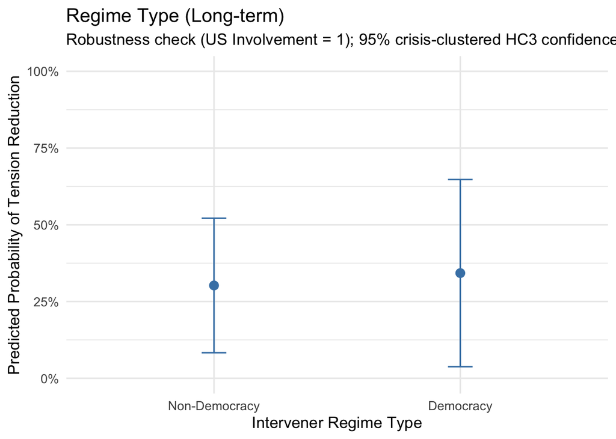

H1.2 Personalism

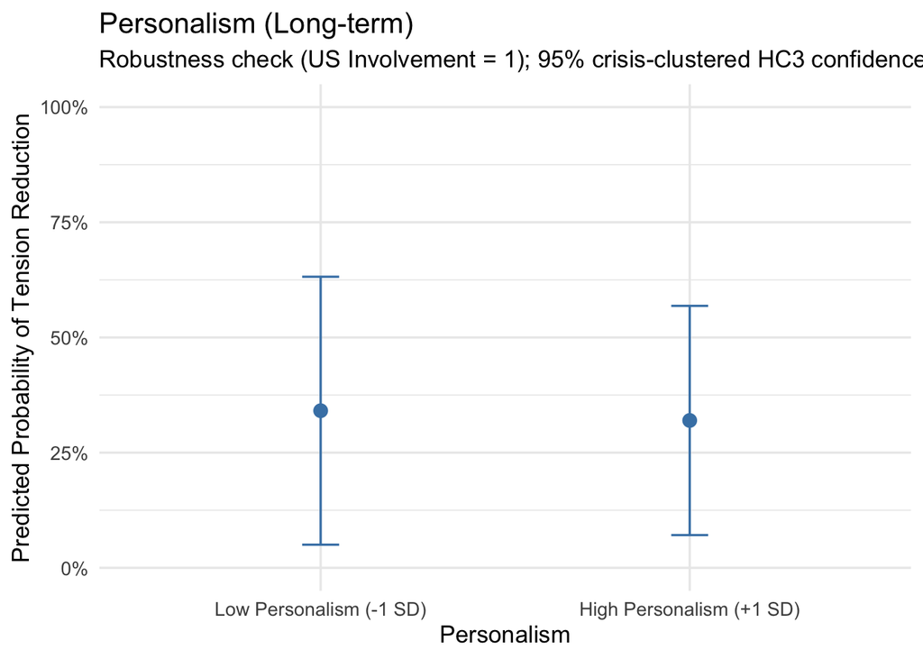

H1.3 Regime Type * Military Expenditure

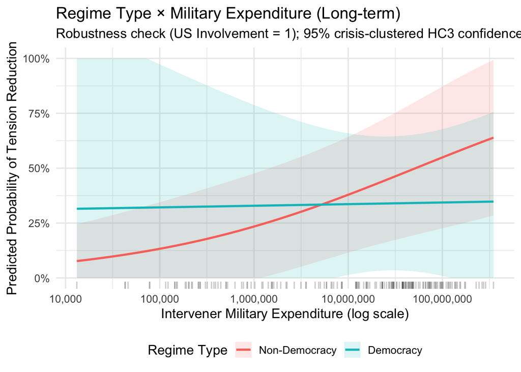

H1.4 Personalism * Military Expenditure

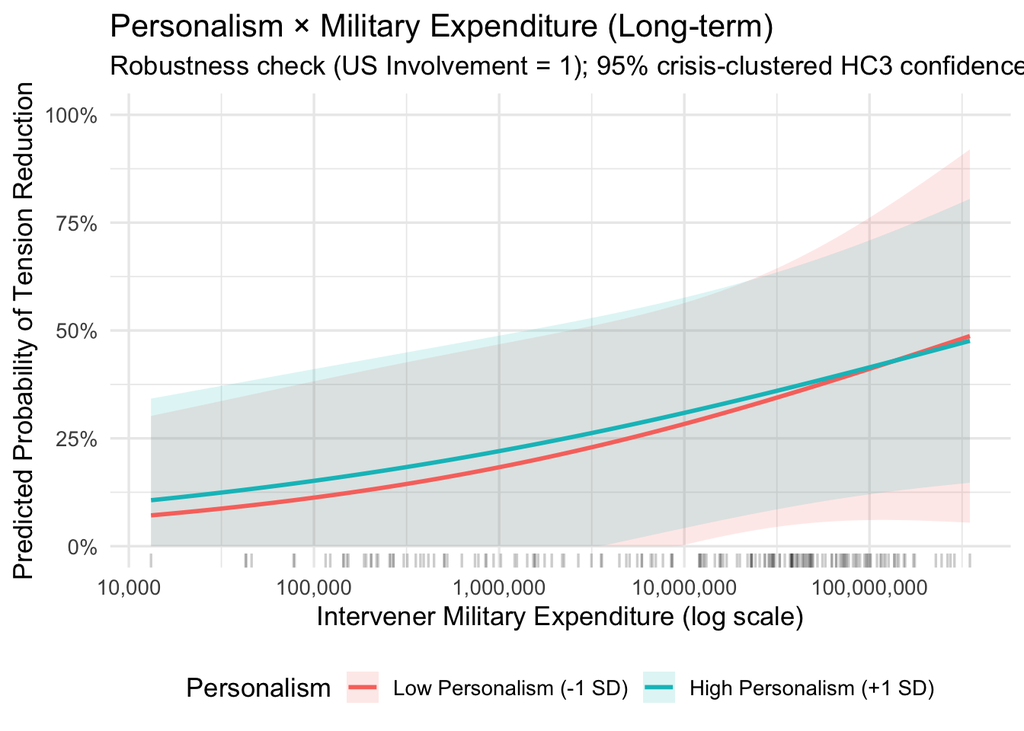

H1.5 Regime Type * Ties to Both Sides

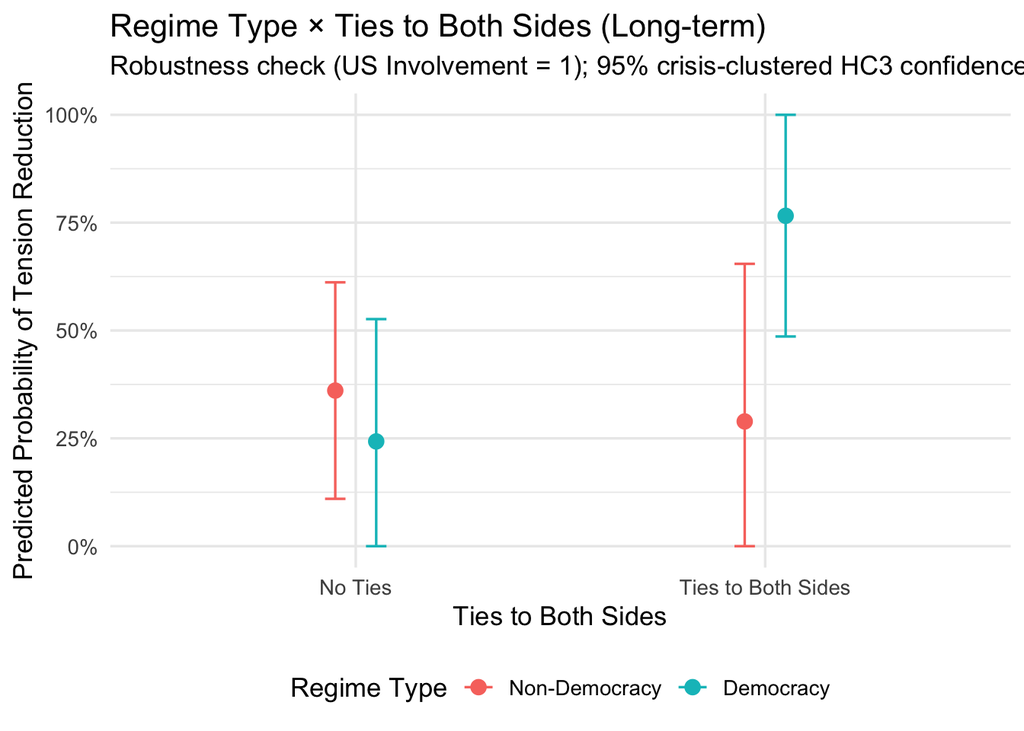

H1.6 Personalism * Ties to Both Sides

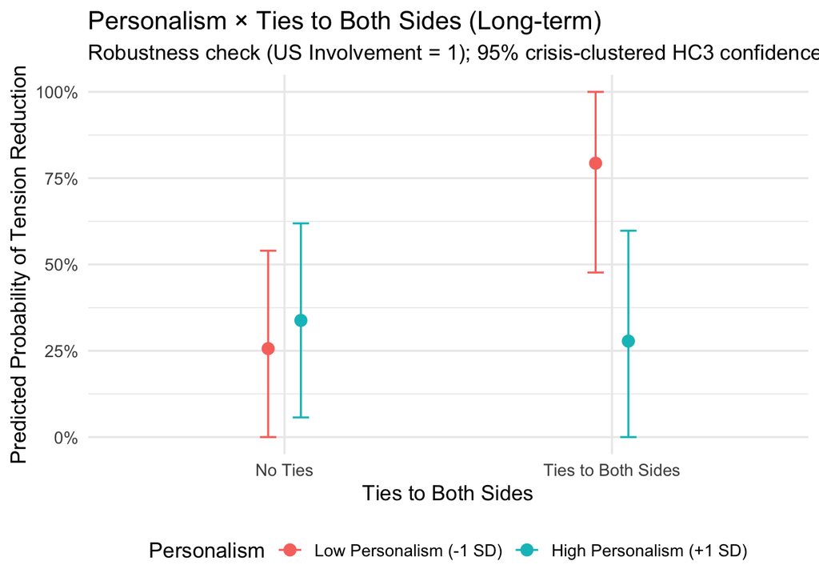

H1.7 Human Rights * Ties to Both Sides

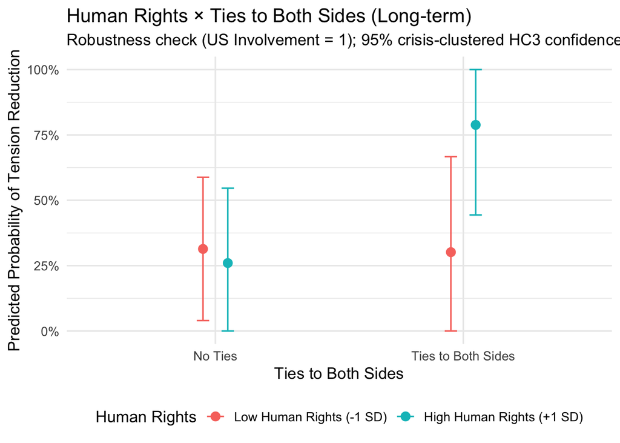

H1.8 Human Rights * Military Expenditure

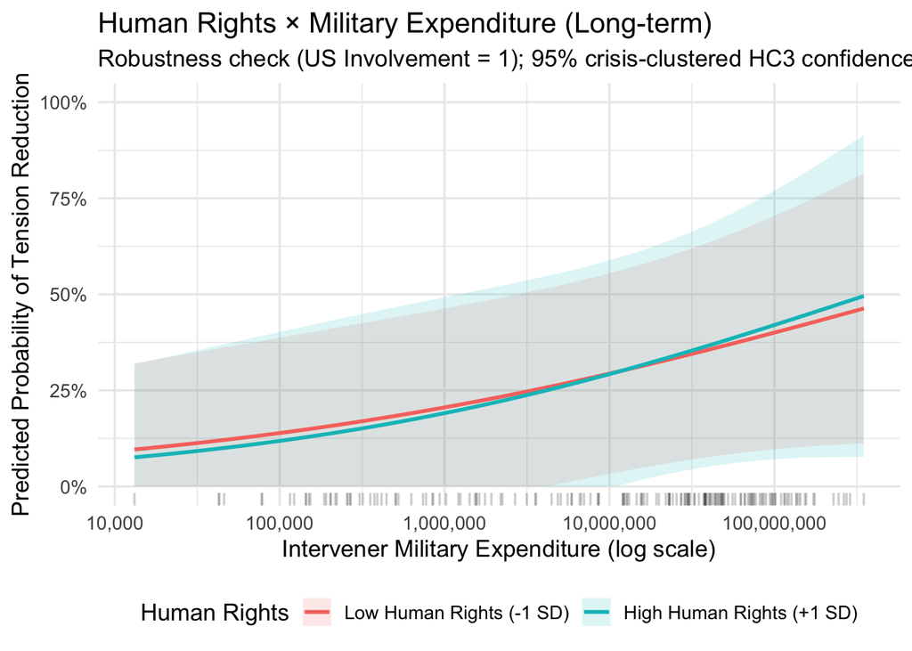

H1.9 Electoral Democracy * Military Expenditure